# Classification

Author

Dr. Niloufar Abourashchi and Dr. Thomas Honnor

# Conditional probability reminder

On occasion, we may be interested in a marginal probability, that is a probability irrespective of the outcomes of all other variables. For example, $P(it\ rains\ tomorrow)$ or $P(an\ individual\ develops\ lung\ cancer)$.

A natural estimate of a marginal probability is simply the proportion of the sample which satisfies the given criteria:
$$\begin{align*}
\hat{P}(it\ rains\ tomorrow) &= \frac{no.\ rainy\ days\ in\ the\ sample}{total\ no.\ days\ in\ the\ sample} \\
\hat{P}(an\ individual\ develops\ lung\ cancer) &= \frac{no.\ lung\ cancer\ sufferers\ in\ the\ sample}{total\ no.\ people\ in\ the\ sample}
\end{align*}$$

On other occasions, we may be interested in a conditional probability, that is a probability that one variable takes a specific outcome conditional on the knowledge that another variable (or multiple other variables) takes a specific outcome value. For example, $P(it\ rains\ tomorrow|it\ rained\ today)$ or $P(an\ individual\ develops\ lung\ cancer|they\ smoked\ cigarettes)$. The vertical bar symbol is used to indicate this conditioning.

A natural estimate of a conditional probability is simply the proportion of the sample satisfying the condition which also satisfy the given criteria:
$$\begin{align*}
\hat{P}(it\ rains\ tomorrow|it\ rained\ today) &= \frac{no.\ rainy\ days\ in\ the\ sample\ which\ follow\ another\ rainy\ day}{total\ no.\ days\ in\ the\ sample\ which\ follow\ a\ rainy\ day} \\
\hat{P}(an\ individual\ develops\ lung\ cancer|they\ smoked\ cigarettes) &= \frac{no.\ lung\ cancer\ sufferers\ in\ the\ sample\ who\ smoked\ cigarettes}{total\ no.\ people\ in\ the\ sample\ who\ smoked\ cigarettes}
\end{align*}$$

This is an example of the general result for conditional probabilities:
$$\begin{align*}
P(A|B) &= \frac{P(A\ and\ B)}{P(B)} \\
&= \frac{P(A\cap B)}{P(B)}
\end{align*}$$

Sometimes, we may be interested in reversing the conditional statement. For example, $P(an\ individual\ smoked\ cigarettes|they\ developed\ lung\ cancer)$. This difference between this statement and the previous one may seem subtle, but can be vital. $P(an\ individual\ develops\ lung\ cancer|they\ smoked\ cigarettes)$ could be used to inform a smoker of their chance of developing lung cancer, while $P(an\ individual\ smoked\ cigarettes|they\ developed\ lung\ cancer)$ could be used to infer whether or not smoking cigarettes is common amongst individuals with lung cancer (and therefore perhaps a potential cause).

Confusion abounded with this difference in light of the COVID-19 pandemic and vaccinations, despite [attempted](https://www.theguardian.com/theobserver/commentisfree/2021/apr/25/covid-false-positives-and-conditional-probabilities) [clarifications](https://anthonybmasters.medium.com/conditional-probabilities-and-imperfect-vaccines-a558e86fe510).

The methodology for moving from $P(A|B)$ to $P(B|A)$ is known as Bayes’ theorem:
$$\begin{align*}
P(B|A) = \frac{P(A|B)\times P(B)}{P(A)}
\end{align*}$$
Bayes’ theorem is the foundation of the major statistical subfield of Bayesian statistics.

# Linear regression

## Conditional interpretation of linear regression

In this section and the following ones I write expressions for simple linear regression, but the concepts extend to multiple linear regression.

A standard linear regression model takes the form:
$$\begin{align*}
Y = \beta_0+\beta_1 X + \epsilon
\end{align*}$$
Where $\epsilon$ is independent of $X$ and $mean(\epsilon)=0$ if the assumptions underlying linear regression are satisfied.

An alternative expression for the mean of a random variable is its expected value. We might use the notation $E[X]=mean(X)$.

We therefore have that $P(\epsilon=e|X=x)=P(\epsilon=e)$, and thus $E[\epsilon|X]=E[\epsilon]=0$ by making use of the assumptions outlined above.

Taking the expectation of $Y$ conditional on a specific value of $X$ in the above expression gives:
$$\begin{align*}
E[Y|X=x] &= E[\beta_0+\beta_1 X+\epsilon|X=x] \\
&= E[\beta_0|X=x] +E[\beta_1 X|X=x] + E[\epsilon|X=x] \\
&= \beta_0+\beta_1 x
\end{align*}$$
Where we have made use of the fact that the expectation is a linear operator.

## Expectation in the case of a binary outcome

For a discrete random variable $Y$, we have that:
$$\begin{align*}
E[Y] &= \sum_y y\times P(Y=y)
\end{align*}$$

In the case of a binary random variable, taking the values 0 and 1, we have that:
$$\begin{align*}
E[Y] &= \sum_y y\times P(Y=y) \\
&= 0\times P(Y=0) + 1\times P(Y=1) \\
&= P(Y=1)
\end{align*}$$

## Linear regression for classification into two categories

Combining the two previous results, we may fit a linear regression model to an outcome $Y$ and interpret the predictions provided by this model as conditional estimates of the outcome, $P(Y=1|X=x)$.

$$\begin{align*}
E[Y|X=x] &= P(Y=1|X=x) \\
&= \beta_0+\beta_1 x
\end{align*}$$

From this, we can interpret $\beta_0+\beta_1 x$ as $P(Y=1|X=x)$. This result can be the basis of a classification procedure. If $P(Y=1|X=x)$ is large, we would classify observation $x$ in the category corresponding to $Y=1$, and vice versa.

A natural question is, “how large is large enough?”. After a little bit of thought, it hopefully seems reasonable to consider $P(Y=1|X=x)=0.5$ as our threshold. After rearranging:
$$\begin{align*}
P(Y=1|X=x) &= \beta_0+\beta_1 x \\
P(Y=1|X=x) &= 0.5 \\
\Rightarrow \beta_0+\beta_1 x &= 0.5 \\
\Rightarrow x &= \frac{0.5-\beta_0}{\beta_1}
\end{align*}$$
This threshold value of $x$ may be referred to as a decision boundary.

## Application

The `mf_training.Rda` and `mf_test.Rda` files are R data files, which can be read directly into the working environment.

```r
library(tidyverse)
```

```r
load("mf_training.Rda")
head(mf_training)
```

```
  gender height hair glasses   eye
1      1    162 17.9       0 other
2      1    166 19.0       0 other
3      1    165 14.8       0 brown
4      1    170 18.7       0 brown
5      1    166 18.6       0  blue
6      1    167 16.1       0 brown
```

The `gender` variable uses a 1 to indicate that an individual is female and a 0 for a male. This 0/1 classification is important for the results of our previous discussion to hold.

We can fit a simple linear regression model for the outcome `gender` using the covariate `height`.

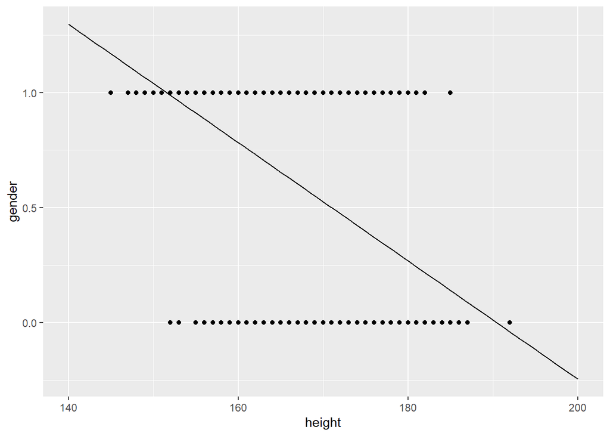

```r
model_1 <- lm(gender ~ height, data=mf_training)

height_grid <- tibble(height=seq(140,200,length.out=100))
height_grid$gender <- predict(model_1, newdata=height_grid)
ggplot(mapping=aes(y=gender, x=height)) +
  geom_point(data=mf_training) +
  geom_line(data=height_grid)
```

We can view a summary of the model, to see that the estimated coefficients are $\hat{\beta}_0=4.90$ and $\hat{\beta}_1=-0.03$.

```r
summary(model_1)
```

```
Call:
lm(formula = gender ~ height, data = mf_training)

Residuals:
    Min      1Q  Median      3Q     Max
-0.9889 -0.4490  0.1910  0.3710  0.8596

Coefficients:
             Estimate Std. Error t value Pr(>|t|)
(Intercept)  4.897180   0.335888   14.58   <2e-16 ***
height      -0.025712   0.002008  -12.80   <2e-16 ***
---
Signif. codes:  0 '***' 0.001 '**' 0.01 '*' 0.05 '.' 0.1 ' ' 1

Residual standard error: 0.4545 on 998 degrees of freedom
Multiple R-squared:  0.1411,    Adjusted R-squared:  0.1403
F-statistic:   164 on 1 and 998 DF,  p-value: < 2.2e-16
```

```r
db <- (0.5-model_1$coefficients[[1]])/model_1$coefficients[[2]]
db
```

```
[1] 171.0162
```

Thus, if an individual has a height less than 171cm we might classify them as female, with individuals with a height greater than 171cm classified as male.

We can check the accuracy of our predictor.

```r
mf_training$pred <- predict(model_1)
mf_training$pred_gender <- if_else(mf_training$pred < 0.5, 0, 1)

table(predicted=mf_training$pred_gender,actual=mf_training$gender)
```

```
         actual
predicted   0   1
        0 180  79
        1 220 521
```

```r
sum(mf_training$pred_gender!=mf_training$gender)/nrow(mf_training)
```

```
[1] 0.299
```

As with other approaches, a validation set approach may be more appropriate to quantify the accuracy of predictions in this case. We can therefore use the model built with the training data to make predictions for the test data and quantify the resulting accuracy.

```r
load("mf_test.Rda")
nrow(mf_test)
```

```
[1] 1000
```

```r
mf_test$pred <- predict(model_1, newdata=mf_test)
mf_test$pred_gender <- if_else(mf_test$pred < 0.5, 0, 1)

table(predicted=mf_test$pred_gender,actual=mf_test$gender)
```

```
         actual
predicted   0   1
        0 209  75
        1 289 427
```

```r
sum(mf_test$pred_gender!=mf_test$gender)/nrow(mf_test)
```

```
[1] 0.364
```

The decision boundary doesn’t necessarily have to be fixed at $P(Y=1|X=x)=0.5$. That threshold in the probability can be tweaked, to a value which optimises prediction accuracy.

## Concerns

There is some merit to the approach outlined above, in making use of our existing knowledge of simple linear regression to produce a classifier.

However, if we focus on the fact that the model builds predictions for $P(Y=1|X=x)$, we need to be cautious.

$P(Y=1|X=x)$ should only take values in the range $[0,1]$. However, $\beta_0+\beta_1 x$ can take values in the range $(-\infty,\infty)$. This is problematic.

Similarly, our earlier workings suggested that an approach like this might be reasonable, if the assumptions of linear regression are satisfied. Can those assumptions realistically be satisfied for a model like this?

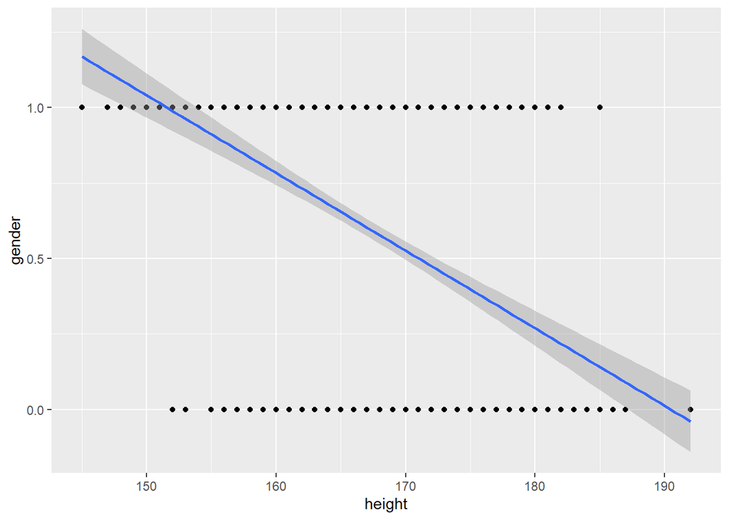

```r
ggplot(mapping=aes(y=gender, x=height),data=mf_training) +
  geom_point(data=mf_training) +
  geom_smooth(method=lm)
```

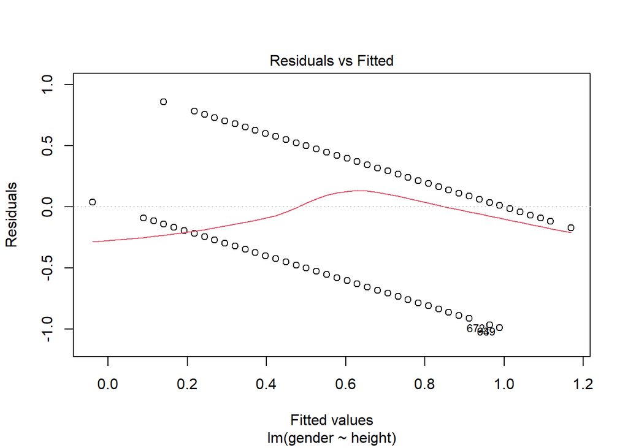

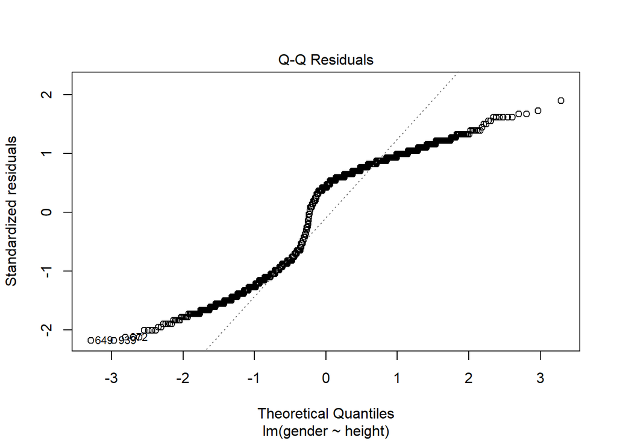

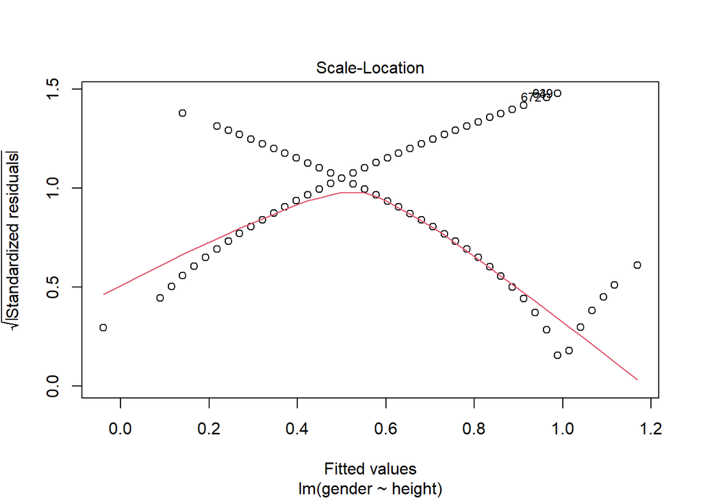

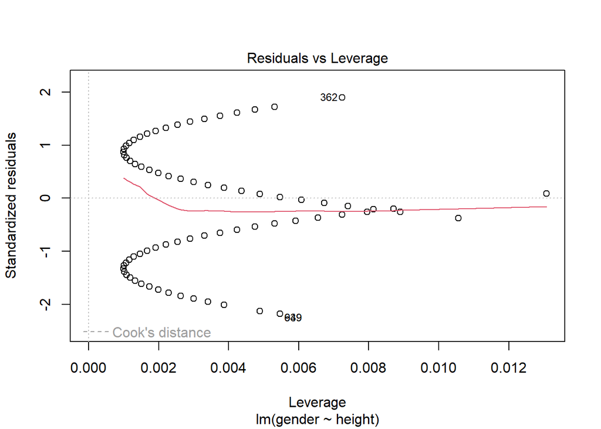

```r
plot(model_1)
```

# Logistic regression

We identified in the previous discussion that we might try to relate $P(Y=1|X=x)$ to a linear predictor of the form $\beta_0+\beta_1 x$. It was perhaps not wise to directly equate these two, on the basis that they are differently constrained.

An alternative might be to relate a function of $P(Y=1|X=x)$, $g(P(Y=1|X=x))$ say, to the linear predictor $\beta_0+\beta_1 x$. This is the foundation of the broader class of generalised linear models. Under this framework, $g()$ is referred to as the link function.

Logistic regression is one example of a generalised linear model which suits our requirements here. The link function is the logit function:
$$\begin{align*}
g(\mu) &= \log\left(\frac{\mu}{1-\mu}\right)
\end{align*}$$
The logit function takes values in $[0,1]$ and transforms them to the range $(-\infty,\infty)$.

Our logistic regression model is therefore of the form:
$$\begin{align*}
\log\left(\frac{P(Y=1|X=x)}{1-P(Y=1|X=x)}\right) = \beta_0+\beta_1 x
\end{align*}$$
The left hand side of this expression is commonly referred to as the log odds.

A fitting procedure can be used to determine estimates of the model parameters, $\beta_0$ and $\beta_1$, via the `glm` function in R and setting `family=binomial`. There is nothing preventing a logistic regression model from including multiple covariates, higher powers of covariates, interactions, etc. but we’re restricting the presentation here to a single covariate to make things less complicated.

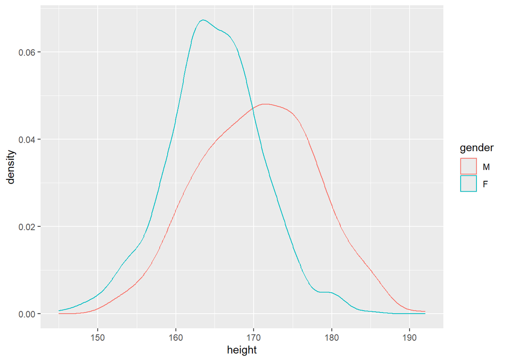

```r
mf_training %>%
  mutate(gender=factor(gender, labels=c("M","F"))) %>%
  ggplot() +
  geom_density(mapping=aes(x=height, color=gender))
```

```r
model_logreg <- glm(gender ~ height,
                    data=mf_training,
                    family=binomial)

summary(model_logreg)
```

```
Call:
glm(formula = gender ~ height, family = binomial, data = mf_training)

Coefficients:
            Estimate Std. Error z value Pr(>|z|)
(Intercept) 21.07065    1.87391   11.24   <2e-16 ***
height      -0.12329    0.01115  -11.06   <2e-16 ***
---
Signif. codes:  0 '***' 0.001 '**' 0.01 '*' 0.05 '.' 0.1 ' ' 1

(Dispersion parameter for binomial family taken to be 1)

    Null deviance: 1346.0  on 999  degrees of freedom
Residual deviance: 1195.2  on 998  degrees of freedom
AIC: 1199.2

Number of Fisher Scoring iterations: 3
```

The R output indicates:
$$\begin{align*}
\log\left(\frac{P(Y=1|X=x)}{1-P(Y=1|X=x)}\right) = 21.1-0.1x
\end{align*}$$

We often want to use a logistic regression model to make predictions for $P(Y=1|X=x)$, for which we can rearrange the general model expression.
$$\begin{align*}
\log\left(\frac{P(Y=1|X=x)}{1-P(Y=1|X=x)}\right) &= \beta_0+\beta_1 x \\
\Rightarrow P(Y=1|X=x) &= \frac{1}{1+\exp(-(\beta_0+\beta_1 x))}
\end{align*}$$
The expression on the right hand side is the logistic function, the inverse of the logit function, which is how logistic regression gets its name.

It is a challenge to visualise the shape of this function purely in our heads, so it makes sense to plot it.

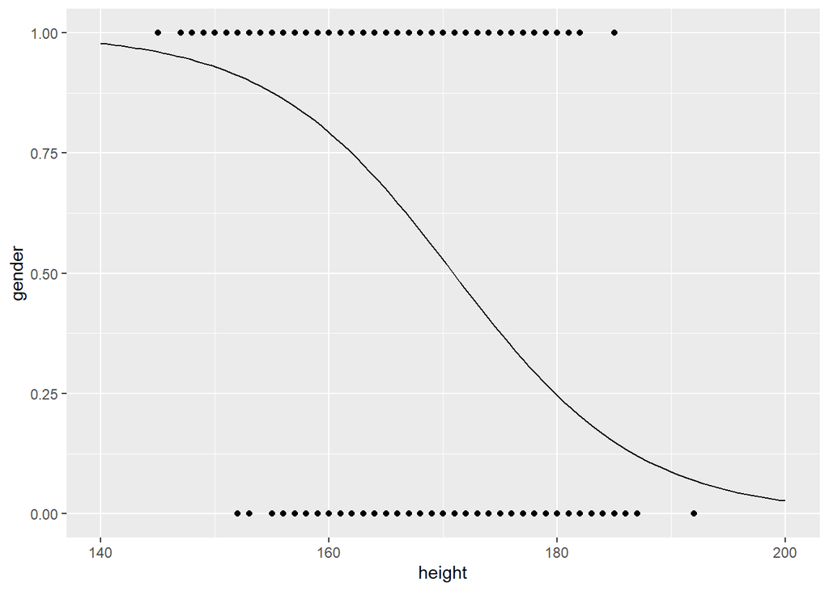

```r
mf_fit <- tibble(height=seq(140,200,length.out=100))

mf_fit$gender <- predict(model_logreg,
                         newdata=mf_fit,
                         type="resp")

ggplot(mapping=aes(y=gender, x=height)) +
  geom_point(data=mf_training) +
  geom_line(data=mf_fit)
```

The predicted probabilities are certainly more reasonable.

We can again determine the decision boundary, the value of $x$ for which $P(Y=1|X=x)=0.5$.
$$\begin{align*}
\log\left(\frac{P(Y=1|X=x)}{1-P(Y=1|X=x)}\right) &= \beta_0+\beta_1 x \\
P(Y=1|X=x) &= 0.5 \\
\Rightarrow 0 &= \beta_0+\beta_1 x \\
\Rightarrow x &= \frac{-\beta_0}{\beta_1}
\end{align*}$$

```r
db_logreg <- (-model_logreg$coefficients[[1]])/model_logreg$coefficients[[2]]
db_logreg
```

```
[1] 170.902
```

```r
db
```

```
[1] 171.0162
```

```r
mf_training$pred <- predict(model_logreg,type="resp")
mf_training$pred_gender <- if_else(mf_training$pred < 0.5, 0, 1)

table(predicted=mf_training$pred_gender,actual=mf_training$gender)
```

```
         actual
predicted   0   1
        0 204  99
        1 196 501
```

```r
sum(mf_training$pred_gender!=mf_training$gender)/nrow(mf_training)
```

```
[1] 0.295
```

```r
mf_test$pred <- predict(model_logreg,type="resp",newdata=mf_test)
mf_test$pred_gender <- if_else(mf_test$pred < 0.5, 0, 1)

table(predicted=mf_test$pred_gender,actual=mf_test$gender)
```

```
         actual
predicted   0   1
        0 228  96
        1 270 406
```

```r
sum(mf_test$pred_gender!=mf_test$gender)/nrow(mf_test)
```

```
[1] 0.366
```

The differences between logistic regression and linear regression mean that the model coefficients are estimated via a different procedure and that the assumptions which much be satisfied differ. Information on these can all be found in any suitable reference book.

As with the previous discussion, it is wise to quantify the error of an approach like this on a separate test set. We can also build logistic regression models with more covariates, higher powers of covariates, interactions, etc. – essentially everything which we can do with a linear regression model. Also as previously, it may make sense for us to place the decision threshold somewhere other than 0.5 and we could gain insight into this via cross-validation.

# Classification in the case of more than two outcome categories

## Introduction

While it is possible, it isn’t at all clear how we would extend our logistic regression model to accommodate more than two outcome categories (an outcome variable which is multinomial, rather than binary/binomial).

Linear Discriminant Analysis (LDA) is an alternative approach in the case where we have two or more outcome categories. The theory underlying LDA relies upon those conditional probability ideas worked through earlier, and in particular application of Bayes’ theorem.

For example, we may assume that the distributions of $X|Y=y$ are normal, where these distributions have different means, but the same variance. In that case, it is possible to follow through the algebra and apply Bayes’ theorem to obtain the distribution of $Y|X$, obtaining $P(Y=y|X=x)$ which we might then use for classification in the same manner as the previous discussions (prediction for $X=x$ the category with the highest value of $P(Y=y|X=x)$). The theoretical details are beyond the level of this course, but can be found in any reasonable reference book.

If we assume that $X|Y=y$ are normally distributed, with different means and different variances then we can make use of a more advanced method, Quadratic Discriminant Analysis (QDA).

## Example

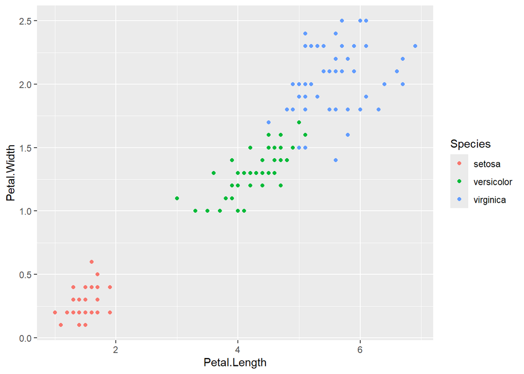

```r
data(iris)

ggplot(data=iris, mapping=aes(x=Petal.Length,
                              y=Petal.Width,
                              color=Species)) +
  geom_point()
```

```r
iris_simple <- iris %>%
  filter(Species == "virginica" | Species=="versicolor") %>%
  select(Species, Sepal.Length, Sepal.Width) %>%
  mutate(is_versicolor = if_else(Species == "versicolor", 1, 0),
         Species = droplevels(Species))

# note the drop levels command updates the factor levels
# to reflect it only contains entries for 2 Species

head(iris_simple)
```

```
     Species Sepal.Length Sepal.Width is_versicolor
1 versicolor          7.0         3.2             1
2 versicolor          6.4         3.2             1
3 versicolor          6.9         3.1             1
4 versicolor          5.5         2.3             1
5 versicolor          6.5         2.8             1
6 versicolor          5.7         2.8             1
```

```r
logistic.model <- glm( is_versicolor ~ Sepal.Length + Sepal.Width,
                    data=iris_simple,family=binomial)

logistic.model.prediction <- if_else( predict(logistic.model,type='resp') > 0.5,
                                      'versicolor',
                                      'virginica')

table(predicted=logistic.model.prediction,actual=iris_simple$Species)
```

```
            actual
predicted    versicolor virginica
  versicolor         38        13
  virginica          12        37
```

```r
correct <- sum(logistic.model.prediction == iris_simple$Species)
correct
```

```
[1] 75
```

```r
incorrect <- sum(logistic.model.prediction != iris_simple$Species)
incorrect
```

```
[1] 25
```

```r
library(MASS)
select <- dplyr::select

lda.model <- lda(Species ~ Sepal.Length+Sepal.Width, data = iris_simple)

lda.model.prediction <- predict(lda.model)$class
table(predicted=lda.model.prediction,actual=iris_simple$Species)
```

```
            actual
predicted    versicolor virginica
  versicolor         38        13
  virginica          12        37
```

```r
table(LDA=lda.model.prediction,LR=logistic.model.prediction)
```

```
            LR
LDA          versicolor virginica
  versicolor         51         0
  virginica           0        49
```

```r
lda.model <- lda(Species ~ Sepal.Length+Sepal.Width, data = iris)

lda.model.prediction <- predict(lda.model)$class

table(predicted=lda.model.prediction,actual=iris$Species)
```

```
            actual
predicted    setosa versicolor virginica
  setosa         49          0         0
  versicolor      1         36        15
  virginica       0         14        35
```

```r
correct <- sum(lda.model.prediction == iris$Species)
correct
```

```
[1] 120
```

```r
incorrect <- sum(lda.model.prediction != iris$Species)
incorrect
```

```
[1] 30
```

```r
qda.model <- qda(Species ~ Sepal.Length+Sepal.Width, data = iris)

qda.model.prediction <- predict(qda.model)$class

table(predicted=qda.model.prediction,actual=iris$Species)
```

```
            actual
predicted    setosa versicolor virginica
  setosa         49          0         0
  versicolor      1         37        16
  virginica       0         13        34
```

```r
correct = sum(qda.model.prediction == iris$Species)
correct
```

```
[1] 120
```

```r
incorrect = sum(qda.model.prediction != iris$Species)
incorrect
```

```
[1] 30
```